# Sesión introductoria

Técnicas de aprendizaje de máquina

Oscar Bustos

# Presentación

## ¡Presenta a tu Socio!

¡Hola a todos!

**Dinámica Inicial**

Comparte lo siguiente sobre tu socio:

**Nombre**, semestre, su **profesión ideal**, dónde les gustaría **emprender** y qué les llama la **atención** sobre esta clase.

## Estadísticas de Clase

**Total de estudiantes:** 23

Ciencia: 15 | Ingeniería: 7 | Intercambio: 1

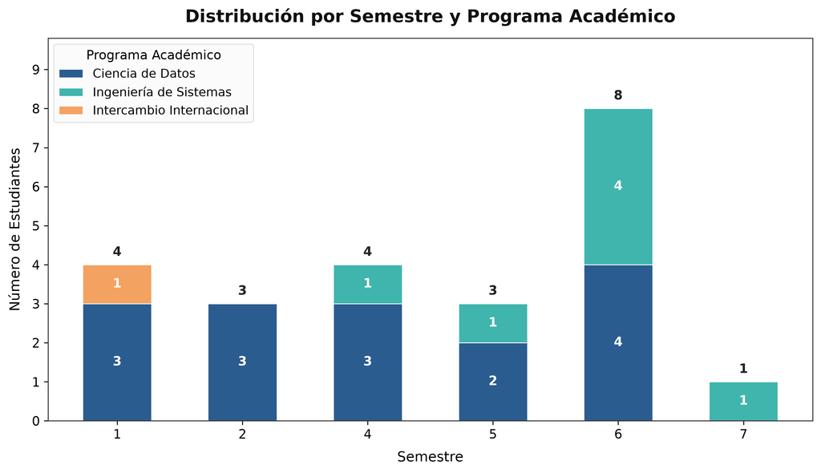

## ¡Conozcámonos!

- Soy Oscar Bustos
- Ingeniero Metratrónico, PhD. (c) en Ingeniería - PUJ
- Docente Javeriano, Tech Manager en Mercadolibre
- Me gusta todo lo relacionado con IA / Advanced Analytics

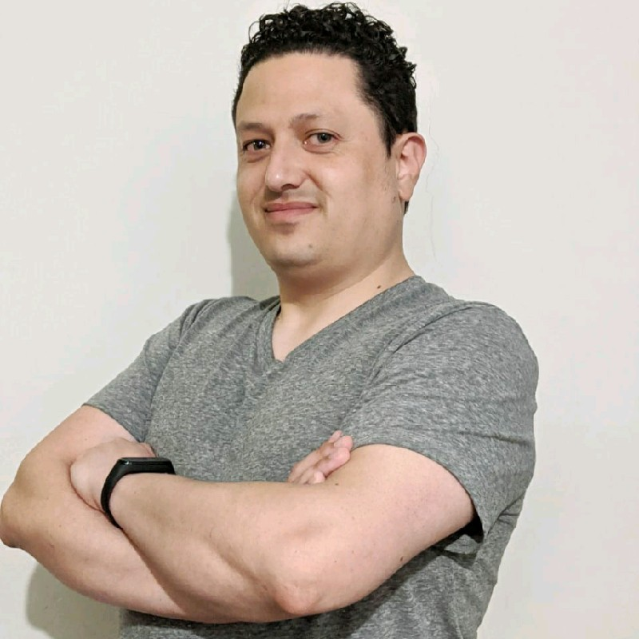

# Logística del Curso

## Estructura del Curso

- **Exposición**
  - Exposición 10%
- **Talleres**
  - Talleres 40%
  - Un taller por clase
- **Proyecto Final**
  - Entrega 1: 25%
  - Entrega 2: 25%

## Reglas del Curso

- 📅 **Horario:** 7:10 am - 9:45 am (descanso 8:30 am).
- 💻 **Entregas:** Talleres en parejas cada domingo (11:59 pm) vía Campus Virtual.
- 👥 **Proyecto Final:** Grupos de 4 personas.
- 🤖 **Uso de IA:** Clase amigable con IA (Gemini/ChatGPT) para programar.
- 🚭 **Convivencia:** No consumir alimentos, ni fumar/vapear en el salón.

## Lecturas y Videos

- Todas las clases hay una lectura previa y un video recomendado
- Todos los libros se encuentran en la plataforma de Springer Nature y O’Reilly
- Se puede acceder a través de los recursos virtuales de la biblioteca en el siguiente enlace: https://javeriana.libguides.com/az.php?a=o

## Libros de la Clase

[figure not shown]

[figure not shown]

[figure not shown]

## Cronograma

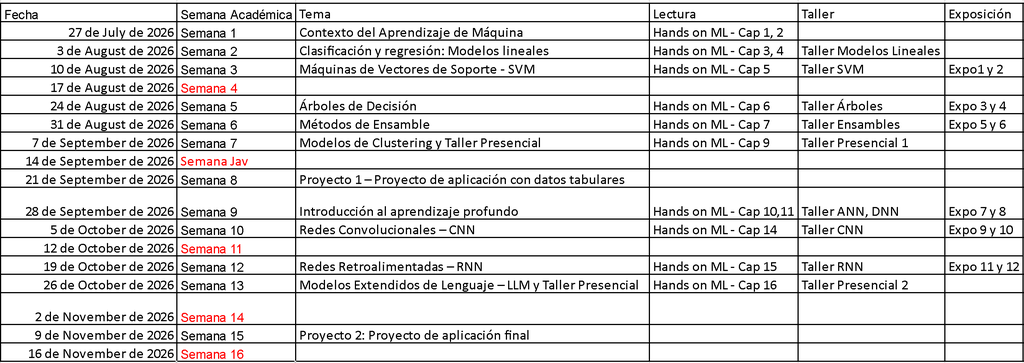

## Tarea / Asignación

**Actividades a desarrollar:**

1. Leer capítulo 1 del libro *Hands-On Machine Learning with Scikit-Learn*.
2. Explorar el [Cuaderno de Google NotebookLM](https://notebooklm.google.com/notebook/06494c56-a1b5-4bf6-a22f-5cd8af948a36):
   - Revisar la infografía.
   - Realizar los quices incluidos.
   - Escuchar el podcast.

# El Problema

## Imaginen esto…

Su jefe les pide construir un **filtro de spam** corporativo.

- ¿Cómo lo harían?
- ¿Qué reglas escribirían y cuántas necesitarían?

**Actividad en Equipos (5 min)**

👥 Reúnanse en sus grupos de trabajo y propongan su aproximación inicial.

## La Aproximación Tradicional

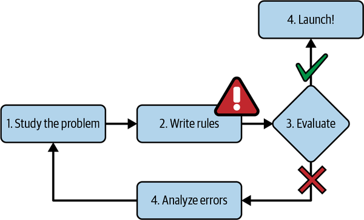

Fuente: (Géron 2022), Capítulo 1

## Contexto Corporativo: BRMS

Los sistemas de reglas sí se usan en empresas y se llaman **BRMS** (*Business Rules Management Systems*), como **Drools** o **Camunda**.

- ⚖️ **Determinismo:** Para reglas estrictas, donde no se admite el error probabilístico de una IA.
- 🔍 **Auditabilidad:** Permiten explicar el paso a paso exacto detrás de cada decisión tomada.
- 🤝 **Autonomía:** Analistas de negocio pueden modificar la lógica operativa en producción sin escribir código.

## El problema de las reglas

Escribieron reglas para “4U”, “gratis”, “crédito fácil”. Pero ahora escriben **“For U”**, **“gr4tis”**, **“crëdito”**. - ¿Qué hacen? ¿Escriben más reglas? ¿Cuándo termina ese ciclo? - ¿Y si el problema es detectar **fraude bancario** o **tumores en imágenes**?

**Discusión**

💬 Analicemos en detalle por qué las reglas manuales fallan en problemas del mundo real.

## Problemas que desbordan las reglas

Las reglas manuales no escalan en:

- 🗣️ Reconocimiento de voz
- 🖼️ Clasificación de imágenes
- 💳 Detección de fraude
- 📈 Predicción de demanda

¿Qué herramienta puede **aprender** las reglas por sí misma?

# La Herramienta: Machine Learning

## ¿Qué es Machine Learning?

Si no podemos escribir todas las reglas… ¿y si dejamos que la **computadora las descubra** a partir de los datos?

- ¿Cómo se imaginan que la computadora “aprende” sin que le programemos las reglas explícitamente?

## Definiendo Machine Learning (Consolidación)

Las definiciones clásicas de la disciplina:

- **Arthur Samuel (1959):** > “El campo de estudio que da a las computadoras la habilidad de aprender sin ser explícitamente programadas.”
- **Tom Mitchell (1997):** > “Un programa aprende de la **experiencia $E$** con respecto a una **tarea $T$** y una **medida de rendimiento $P$**, si su rendimiento en $T$, medido por $P$, mejora con $E$.”

## ML como respuesta al problema

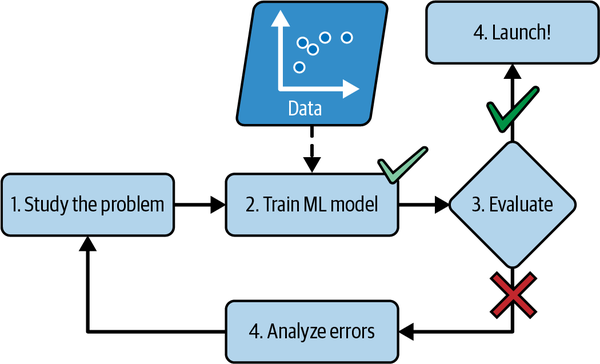

Fuente: (Géron 2022), Capítulo 1

## Adaptación al Cambio

¿Recuerdan el problema del spammer que cambia de “4U” a “For U”?

- ¿Qué pasa con un sistema de ML cuando los usuarios marcan esos nuevos correos como spam? ¿Cómo reacciona?

## ML se adapta al cambio (Consolidación)

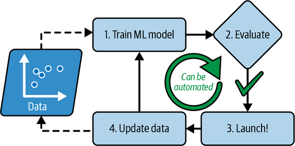

Fuente: (Géron 2022), Capítulo 1

El sistema **aprende automáticamente** los nuevos patrones sin que nadie reescriba las reglas.

## ¿Dónde encaja ML en el universo de la IA?

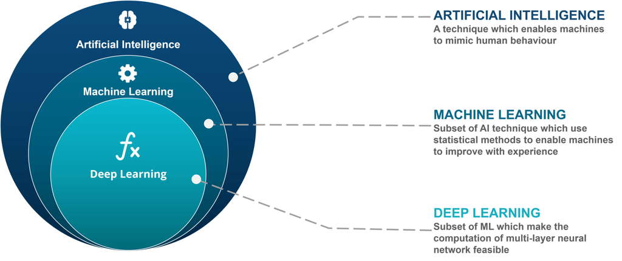

Fuente: [Edureka - AI vs Machine Learning vs Deep Learning](https://www.edureka.co/blog/ai-vs-machine-learning-vs-deep-learning/)

## Definición de Inteligencia Artificial

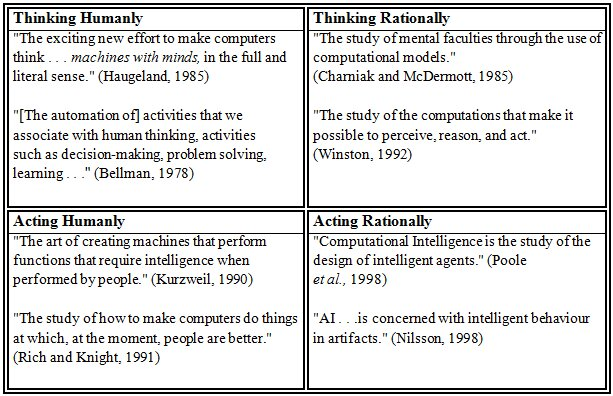

Fuente: (Russell and Norvig 2020)

## ¿Por qué ahora?

Si la IA ya existía en los años 50…

- ¿Por qué hasta ahora estamos viendo una clase sobre esto en la universidad como algo ‘nuevo’?

## Consolidación: La Tormenta Perfecta

¿Por qué despegó la IA/ML en la última década?

- 📊 **Big Data:** Disponibilidad masiva de datos digitalizados.
- ⚡ **Cómputo:** Evolución de GPUs, TPUs y almacenamiento en la nube.
- 🧠 **Algoritmos y Frameworks:** Bibliotecas open-source accesibles (Scikit-Learn, PyTorch).
- 💼 **Valor de Negocio:** Casos de éxito comerciales e impacto económico real.

## ¿Cuándo usar ML?

ML es ideal cuando:

- **Reglas complejas:** El problema requiere listas interminables de reglas difíciles de mantener.
- **Problemas sin algoritmo conocido:** No existe una fórmula explícita (ej. reconocimiento de voz).
- **Entornos cambiantes:** Los datos evolucionan constantemente y el sistema debe adaptarse.
- **Descubrimiento de patrones:** Queremos extraer conocimiento oculto de grandes volúmenes de datos (**Data Mining**).

# ¿Cómo funciona?

## ¿Cómo “aprende” una máquina?

- Si les muestro 1000 fotos de gatos y 1000 de perros etiquetadas… ¿es **supervisado** o **no supervisado**?
- ¿Y si les doy las 2000 fotos **sin etiquetas** y les pido agruparlas?

## Aprendizaje Supervisado

Los datos de entrenamiento incluyen la **respuesta correcta** (etiquetas/labels):

- **Clasificación:** Asignar una categoría (Spam/Ham, Gato/Perro, Benigno/Maligno).
- **Regresión:** Predecir un valor numérico (precio de una casa, temperatura mañana).

*El modelo aprende la relación entre las entradas (features) y las salidas (labels).*

## Aprendizaje No Supervisado

Los datos **no tienen etiquetas**. El sistema busca estructura por sí mismo:

- **Clustering:** Agrupar clientes similares para marketing segmentado.
- **Reducción de dimensionalidad:** Simplificar datos complejos sin perder información esencial.
- **Detección de anomalías:** Identificar transacciones de tarjeta de crédito inusuales.

## Otras formas de aprendizaje

- **Semi-supervisado:** Pocos datos etiquetados + muchos sin etiquetar (ej. Google Photos: agrupa caras automáticamente, luego tú le dices *quién* es).
- **Auto-supervisado (Self-supervised):** Genera sus propias etiquetas (ej. enmascarar una palabra y predecir cuál falta). **Así se entrenan los LLMs.**
- **Aprendizaje por Refuerzo:** Un agente aprende por **ensayo y error**, recibiendo recompensas o castigos (ej. AlphaGo, robots que aprenden a caminar).

## ¿Cómo se entrena?

- ¿Es mejor entrenar con **todos los datos de una vez** o ir aprendiendo **de a poco** conforme llegan datos nuevos?
- ¿Depende del tipo de problema?

## Batch vs. Online Learning

### Batch (Offline)

- 📥 **Datos:** Todos a la vez.
- ⚡ **Cómputo:** Alto tiempo y memoria.
- 🔄 **Cambio:** Reentrena desde cero (*Data Drift*).

### Online (Incremental)

- 🌊 **Datos:** Secuencial o *mini-batches*.
- ⚡ **Cómputo:** Ligero y continuo.
- 🔄 **Cambio:** Ajuste dinámico (*Learning Rate*).

## ¿Cómo generaliza un modelo?

¿Qué estrategia escala mejor y cuál creen que es más interpretable?

- **Memorizar todos los ejemplos** y buscar el más parecido.
- **Construir una fórmula matemática** que resuma los patrones.

## Basado en Instancias

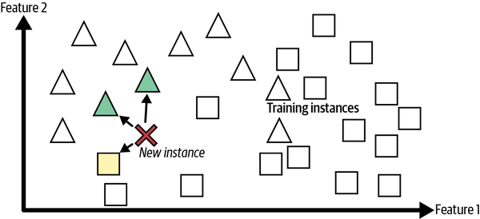

Fuente: (Géron 2022), Capítulo 1

- Memoriza los ejemplos de entrenamiento y clasifica usando **similitud** (distancia).
- *Ejemplo:* **k-Nearest Neighbors** (KNN) - “¿A cuál de mis conocidos se parece más?”

## Basado en Modelos

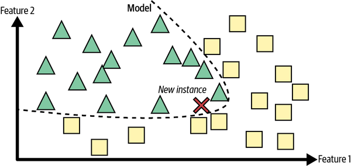

Fuente: (Géron 2022), Capítulo 1

- Construye un modelo matemático ajustando **parámetros** para minimizar una función de costo.
- *Ejemplo:* **Regresión Lineal** - Encuentra la línea que mejor se ajusta a los datos.